# My SpotifyR Report

Author

Eszter Mihalek

# Hablemos de Bad Bunny!

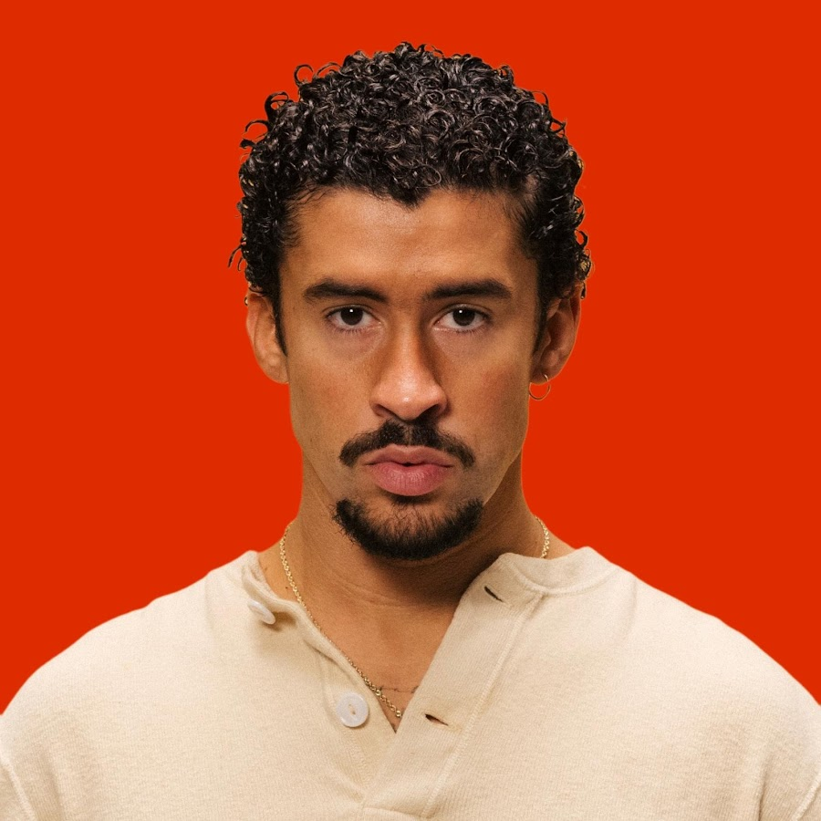

## Who is Bad Bunny?

Bad Bunny (born Benito Antonio Martínez Ocasio in 1994) is a Puerto Rican singer, rapper, and songwriter known for his influence on Latin trap and reggaeton. He gained international fame with his unique blend of reggaeton, Latin trap, and other genres, often incorporating socially conscious themes into his music. His breakthrough came with hits like *Soy Peor*, *Mía* (feat. Drake), and *I Like It* (with Cardi B and J Balvin). He has since released multiple chart-topping albums, including *YHLQMDLG*, *El Último Tour Del Mundo*, and *Un Verano Sin Ti*, and most recently *Debí Tirar Más Fotos,* solidifying his status as one of the most influential Latin artists globally

### His Quote

> *“Be proud to be Latino and never lose that pride!”*

> *“I don’t want to be fake. I’m just being me. And I have the power to break stereotypes and whatever useless rules that society puts on us”*

> - **Bad Bunny**

### His Albums

Album Cover

Album Title & Release Date

- DeBÍ TiRAR MáS FOToS
  - *January 5, 2025*
- nadie sabe lo que va a pasar mañana
  - *October 13, 2023*
- Un Verano Sin Ti
  - *May 6, 2022*
- EL ÚLTIMO TOUR DEL MUNDO
  - *November 27, 2020*
- LAS QUE NO IBAN A SALIR
  - *May 10, 2020*
- YHLQMDLG
  - *February 29, 2020*
- OASIS
  - *June 28, 2019*
- X 100PRE
  - *December 24, 2018*

## My Picks

### My Favorite Albums

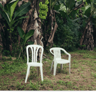

**DeBÍ TiRAR MáS FOToS (2025)**

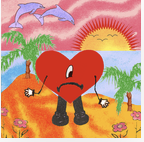

**Un Verano Sin Ti (2022)**

### My All-Time Favorite Song

[Otro Atardecer (2022)](https://youtu.be/i1t3wCxaOlU?si=7zD4kpQzwQEoXcU6)

[video not shown]

### My Favorite Lyrics

> Las 6  
> 6 p. m. frente al río  
> Viéndono’ los corazone’  
> Las hoja’ cayendo, preguntas sin contestacione’  
> Mis sentimiento’ cambian como estacione’  
> Y aunque en PR todo el tiempo es verano  
> Estoy pasando frío escuchando estas cancione’  
> Pensando en ti, pero no te emocione’  
> Porque no te vo’a escribir  
> ¿Cuál de los dos es quien más va a sufrir?  
> No sé, pero ojalá que seas tú, ojalá que seas tú  
> Pa’ mí que vas a ser tú

> …

> **- BOKeTE (2025)**

## Data Analysis

### Data Source

I extracted the data using the `spotifyr` package, and stored it in the data folder.

### Import Data

```r
# install.packages("ggplot2")
# install.packages("dplyr")
# install.packages("knitr")
# Packages needed for analysing the data
library(dplyr)
library(knitr)
library(ggplot2)
library(readr)
library(tidyverse)
# Import data into df

# df <- read.csv("data/BBunny.csv")
df <- read.csv("data/BBunny.csv", sep = ";", header = TRUE)
```

### Take a Glance at the Data Frame

```r
# Slice 5 random records in the dataframe
df |> dplyr::slice_sample(n=5) |> knitr :: kable (digit = 2)
```

| artists | album_name | track_name | popularity | duration_ms | explicit | danceability | energy | key | loudness | mode | speechiness | acousticness | instrumentalness | liveness | valence | tempo | time_signature | track_genre |
| --- | --- | --- | --- | --- | --- | --- | --- | --- | --- | --- | --- | --- | --- | --- | --- | --- | --- | --- |
| J Balvin;Bad Bunny | Clásicos de ahora: Perreo | LA CANCIÓN | 0 | 242573 | FALSE | 0.76 | 0.65 | 7 | -5.80 | 1 | 0.32 | 0.15 | 0 | 0.11 | 0.43 | 176.09 | 4 | latino |
| Bad Bunny;Tainy | Callaita | Callaita | 80 | 250533 | TRUE | 0.61 | 0.62 | 2 | -4.77 | 1 | 0.31 | 0.60 | 0 | 0.24 | 0.24 | 176.17 | 4 | reggaeton |
| J Balvin;Bad Bunny | Esto No Se Le Dedica A Cualquiera | LA CANCIÓN | 2 | 242573 | FALSE | 0.76 | 0.65 | 7 | -5.80 | 1 | 0.32 | 0.15 | 0 | 0.11 | 0.43 | 176.09 | 4 | reggaeton |
| Jhayco;J Balvin;Bad Bunny | Esto me suena a Farra | No Me Conoce - Remix | 1 | 309120 | FALSE | 0.80 | 0.79 | 10 | -3.84 | 0 | 0.07 | 0.14 | 0 | 0.09 | 0.58 | 91.99 | 4 | latino |
| Bad Bunny;Jowell & Randy;Ñengo Flow | YHLQMDLG | Safaera | 80 | 295176 | TRUE | 0.61 | 0.83 | 2 | -4.07 | 1 | 0.38 | 0.01 | 0 | 0.11 | 0.69 | 96.17 | 4 | latino |

## Data Preparation

I have removed all duplicates and albums that Bad Bunny featured in but are not his own albums in my data frame and also removed the live versions of the same songs.

```r
#filter out albums that Bad Bunny only featured in but are not his own (only albums published before 2022 contained in dataset so I am only filtering those out)
BB_original <- c("Un Verano Sin Ti", "EL ÚLTIMO TOUR DEL MUNDO", "LAS QUE NO IBAN A SALIR", "YHLQMDLG", "OASIS", "X 100PRE")

df <- df |> filter(album_name %in% BB_original)

# remove all duplicate tracks
df <- df |> distinct(track_name, .keep_all = TRUE)

# Filter out track names that include "Live at" or "Live Acoustic"
df <- df |> filter(!grepl("Live at|Live Acoustic", track_name))
# Change the data type of album_name from numeric into character
df$album_name <- as.character(df$album_name)
```

### Album Analysis (Valence, Danceability, & Popularity)

#### Valence

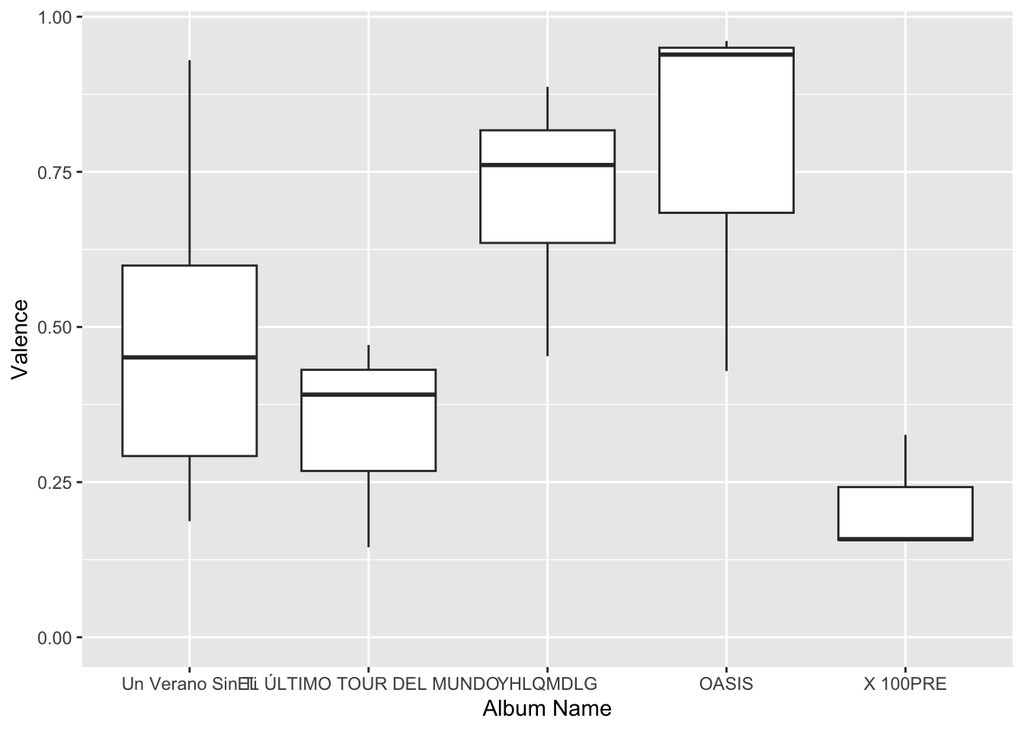

```r
# Change album_name from character to factor before plotting
df$album_name <- as.factor(df$album_name)

# Order the albums based on release year (from latest release to earlier ones)
album_order <- c("Un Verano Sin Ti", "EL ÚLTIMO TOUR DEL MUNDO", "LAS QUE NO IBAN A SALIR", "YHLQMDLG", "OASIS", "X 100PRE")
# Convert album_name into a factor with specified order
df$album_name <- factor(df$album_name, levels = album_order)

# Plot a boxplot
ggplot(df, aes(x=album_name, y=valence))+
  geom_boxplot()+
  ylim(0, NA) +
  labs(x="Album Name", y="Valence")
```

The valence level of the albums fluctuates quite a bit over the different albums but 2 main clusters: positive albums with high valence (OASIS & YHLQMDLG) and lower valence overall more negative albums (Un Verano Sin Ti, EL ÚLTIMO TOUR DEL MUNDO, X 100PRE).

Nonetheless, the distribution of valence data under each album generally seems to be quite skewed.

#### Danceability

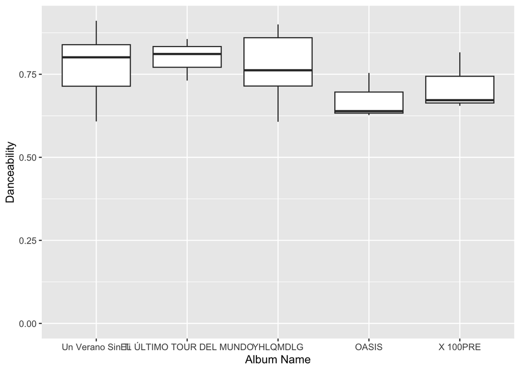

```r
library(ggplot2)
# Plot a boxplot
ggplot(df, aes(x=album_name, y=danceability))+
  geom_boxplot()+
    ylim(0, NA) +
  labs(x="Album Name", y="Danceability")
```

##### Danceability: Zoomed In

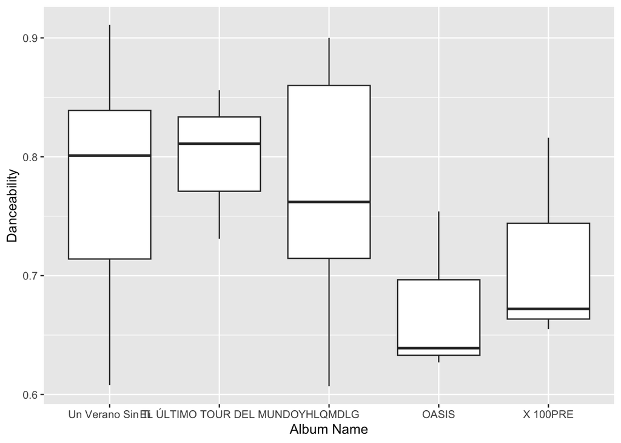

```r
ggplot(df, aes(x=album_name, y=danceability))+
  geom_boxplot()+
  labs(x="Album Name", y="Danceability")
```

#### Scatter Plot: Valence X Danceability

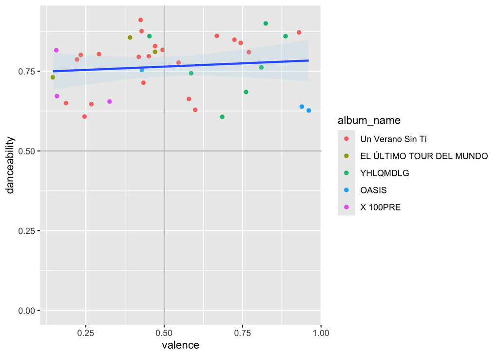

```r
ggplot(df, aes(x=valence, y=danceability))+
  geom_point(aes(color=album_name)) +
    ylim(0, NA) +
  geom_hline(yintercept= 0.5, color="grey")+
  geom_vline(xintercept= 0.5, color="grey")+
  geom_smooth(method = "lm", alpha = 0.2, fill = "lightblue")
```

##### Scatter Plot: Zoomed In

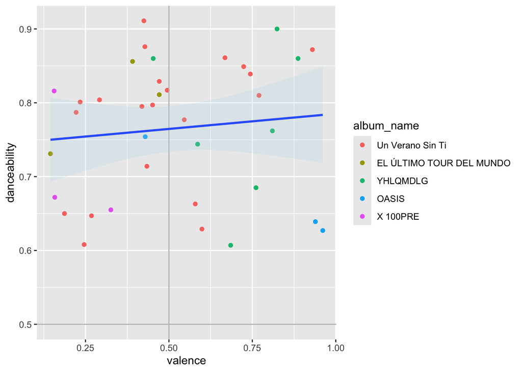

```r
ggplot(df, aes(x=valence, y=danceability))+
  geom_point(aes(color=album_name)) +
  geom_hline(yintercept= 0.5, color="grey")+
  geom_vline(xintercept= 0.5, color="grey")+
  geom_smooth(method = "lm", alpha = 0.2, fill = "lightblue")
```

#### Popularity

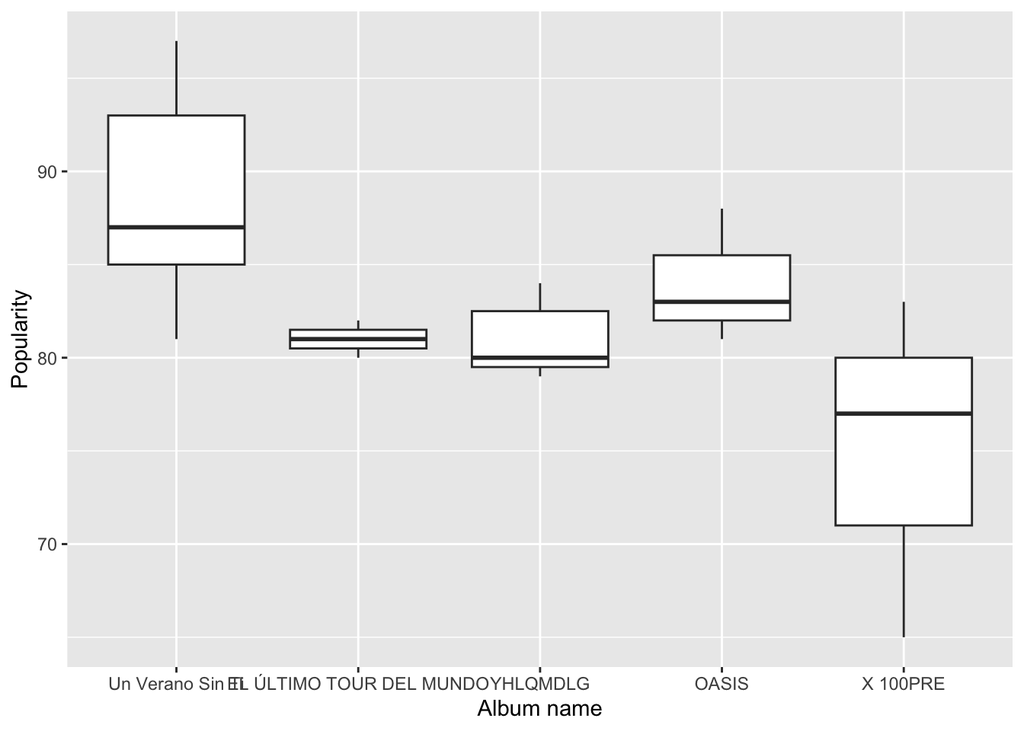

```r
ggplot(df, aes(x=album_name, y=popularity))+
  geom_boxplot()+
  labs(x="Album name", y="Popularity")
```

## Bad Bunny’s Most Positive and Popular Songs

The artist’s TOP3 most positive songs based on their valence score:

```r
df |> slice_max(valence, n=3) |> dplyr::select(track_name, album_name, valence) |> knitr::kable(digits = 2)
```

| track_name | album_name | valence |
| --- | --- | --- |
| UN PESO | OASIS | 0.96 |
| QUE PRETENDES | OASIS | 0.94 |
| Yo No Soy Celoso | Un Verano Sin Ti | 0.93 |

Listen to Bad Bunny’s most positive song, *UN* *PESO,* below:

[video not shown]

The artist’s TOP3 most popular songs (released until 2022):

```r
df |> slice_max(popularity, n=3) |> dplyr::select(track_name, album_name, popularity) |> knitr::kable(digits = 2)
```

| track_name | album_name | popularity |
| --- | --- | --- |
| Me Porto Bonito | Un Verano Sin Ti | 97 |
| Tití Me Preguntó | Un Verano Sin Ti | 97 |
| Efecto | Un Verano Sin Ti | 96 |

Listen *Me Porto Bonito* below:

[video not shown]